# Homework2

1. Suppose we perform a simple linear regression where we obtain
   $$\hat{\beta}_0 = 2.7, r = -0.78, s_x = 4.9, s_y = 20.9, n = 75$$
1. What is the estimated slope of the least squares regression line?

   The estimated slope of the least squares regression line is -0.78

```r
beta0 <- 2.7
r <- -.78
s_x <- 4.9
s_y <- 20.9
n <- 75

beta1 <- r * (s_x / s_x)
beta1
```

```
[1] -0.78
```

2. What percent of the variation in the response variable is explained by a linear regression model?
3. 60.84% of the variation in the response variable is explained by a linear regression model

```r
#creating an object for part c
r_squared <- r^2
#print out percentage
r_squared * 100
```

```
[1] 60.84
```

3. For the simple linear regression model, what are the total sums of squares, model sums of squares and sum of squared errors?

   the total sums of squares is 32323.94, the model sums of squares is 19665.89. and the sum of squared errors is 12658.05

```r
# we know r^2 = ssm/sst
# we also know sst = (n-1) * s_y^2
# and that sst = ssm + sse
sst <- (n - 1) * (s_y * s_y)
ssm <- r_squared * sst
sse <- sst - ssm
sse
```

```
[1] 12658.05
```

```r
ssm
```

```
[1] 19665.89
```

```r
sst
```

```
[1] 32323.94
```

4. Calculate the mean squared error of the linear regression model.

   the mean squared error of the linear regression model is 173.40

```r
k <- 2
mse <- sse / (n - k)
mse
```

```
[1] 173.398
```

5. Calculate a test statistic and p-value for testing for a significant linear relationship between $X$ and $Y$.

   the test statistic F is 113.41, the p-value is 1.629e-16

```r
# reassign ssm to msm for convenience
msm <- ssm
f <- msm/mse
df1 <- k - 1
df2 <- n - k
f <- msm / mse
p_value <- pf(f, df1, df2, lower.tail = FALSE)
f
```

```
[1] 113.4147
```

```r
p_value
```

```
[1] 1.628554e-16
```

2. Fill in the missing values in the following incomplete ANOVA table.

|  | df | Sums of Squares | Mean Square | F Value | Pr(>f) |
| --- | --- | --- | --- | --- | --- |
| Model | 9 | 2126.916 | 236.324 | 4.51 | 5.55e-05 |
| Error | 90 | 4716 | 52.4 |  |  |
| Total | 99 |  |  |  |  |

```r
k <- 10
n <- 100
df1 <- k - 1
df2 <- n - 1
mse <- 52.4
f <- 4.51
msm <- f * mse
sse <- mse * (n - k)
ssm <- msm * (k - 1)
pf(f, df1, df2, lower.tail = FALSE)
```

```
[1] 5.554296e-05
```

3. The dataset *Startups.csv* contains information on a sample of 46 new start-up companies in the United States. The variables listed are
- *R.D.Spend*: The amount of money the company spent on research and development (R&D) in the last year.
- *Administration*: The amount of money the company spent on administrative costs in the last year.
- *Marketing.Spend*: The amount of money the company spent on marketing in the last year.
- *State*: The state in which the company is located
- *Profit*: The company’s profit last year.

Suppose we wish to create a multiple linear regression model for the company’s profits based on all of the additional variables in the dataset.

1. Report the least squares regression line for this linear model.

   $\hat{y} =$ 5.977e04 - 5.759e-02Administration + 7.751e-01R.D.Spend + 2.102e-02Marketing.Spend - 1.752e03StateFlorida - 1.597e03StateNewYork

```r
startups <- read.csv("~/stat408/Homework2/Data/Startups.csv")
mod <- lm(Profit ~ ., startups)
summary(mod)
```

```
Call:
lm(formula = Profit ~ ., data = startups)

Residuals:
   Min     1Q Median     3Q    Max
-15464  -4887  -1424   5550  13560

Coefficients:
                  Estimate Std. Error t value Pr(>|t|)
(Intercept)      5.977e+04  6.126e+03   9.757 3.91e-12 ***
R.D.Spend        7.751e-01  3.909e-02  19.828  < 2e-16 ***
Administration  -5.759e-02  4.515e-02  -1.275    0.210
Marketing.Spend  2.102e-02  1.528e-02   1.376    0.176
StateFlorida    -1.752e+03  2.745e+03  -0.638    0.527
StateNew York   -1.597e+03  2.765e+03  -0.578    0.567
---
Signif. codes:  0 '***' 0.001 '**' 0.01 '*' 0.05 '.' 0.1 ' ' 1

Residual standard error: 7503 on 40 degrees of freedom
Multiple R-squared:  0.9613,    Adjusted R-squared:  0.9565
F-statistic: 198.7 on 5 and 40 DF,  p-value: < 2.2e-16
```

```r
coef(mod)
```

```
    (Intercept)       R.D.Spend  Administration Marketing.Spend    StateFlorida
   5.977309e+04    7.750701e-01   -5.758815e-02    2.102120e-02   -1.752434e+03
  StateNew York
  -1.597229e+03
```

2. Interpret the parameter associated with the explanatory variable Administration in the context of the problem.

```r
library(lmtest)
#breusch-pagan test and residual plot
bptest(mod)
```

```
    studentized Breusch-Pagan test

data:  mod
BP = 3.5033, df = 5, p-value = 0.6229
```

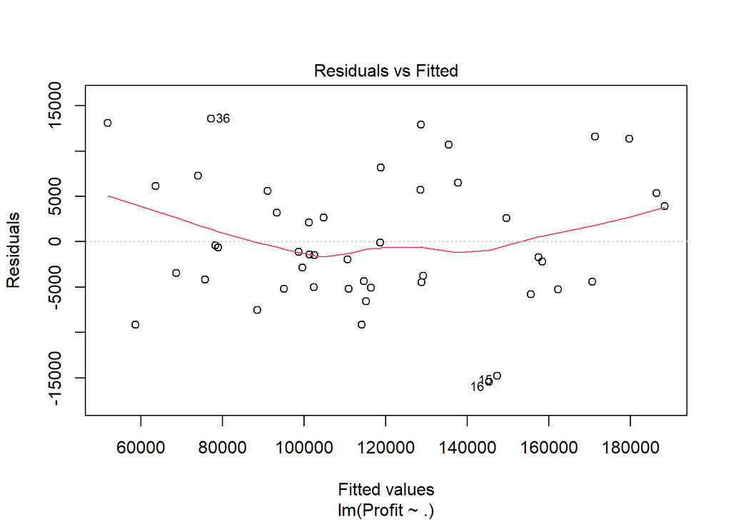

```r
plot(mod,1)
```

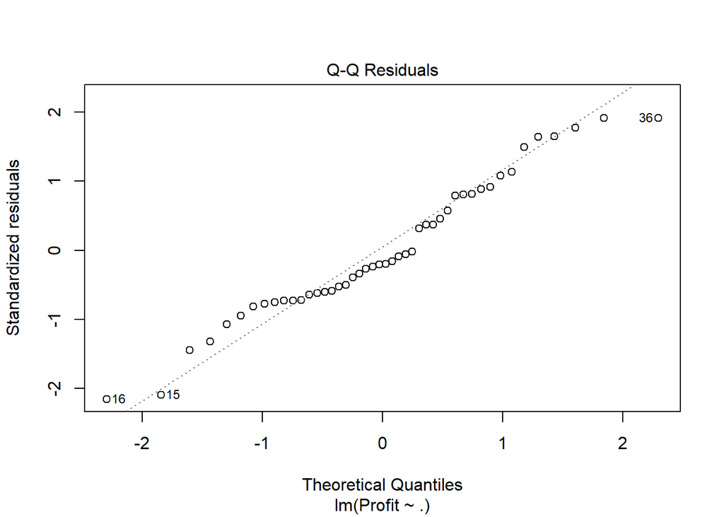

```r
#Q-Q plot and komlogrov smirnov test
plot(mod,2)
```

```r
ks.test(rstandard(mod), "pnorm")
```

```
    Exact one-sample Kolmogorov-Smirnov test

data:  rstandard(mod)
D = 0.11552, p-value = 0.5332
alternative hypothesis: two-sided
```